# Urine Manuscript Analysis

complete

Yinjie Gao

2026-10-14

```r
knitr::opts_chunk$set(
  echo = TRUE,
  message = FALSE,
  warning = FALSE,
  tidy = FALSE,
  results = "asis",
  fig.width = 6,
  fig.height = 4,
  fig.align = "left",
  dev = params$figure_format
)

requireNamespace("patchwork")
requireNamespace("gtsummary")
requireNamespace("pROC")
requireNamespace("ggnewscale")
requireNamespace("ggh4x")
requireNamespace("CIfinder")
set_font <- list(
  ggplot2::theme(strip.text = ggplot2::element_text(size = 12),
                 axis.title = ggplot2::element_text(size = 11),
                 axis.text = ggplot2::element_text(size = 10),
                 legend.title = ggplot2::element_text(size = 10),
                 legend.text = ggplot2::element_text(size = 10),
                 legend.box.background = ggplot2::element_rect(color = "black", linewidth = 0.25))
)
ggplot2::theme_set(ggplot2::theme_bw() + set_font)
```

```r
# Load the analysis-ready Excel workbook produced by urine_ms_data.Rmd.
df_clinical <- openxlsx::read.xlsx(params$data_file, sheet = "Clinical Data")
df_sample   <- openxlsx::read.xlsx(params$data_file, sheet = "Sample Data")

df_master <- df_clinical |>
  dplyr::inner_join(df_sample, by = "participant_id") |>
  dplyr::mutate(
    biofluid = factor(biofluid, levels = c("urine", "plasma")),
    biobank = factor(biobank, levels = c("UCSD", "MGB")),
    cohort = factor(cohort, levels = c("UCSD Training", "MGB Holdout (Baseline)",
                                       "UCSD Holdout (Pre-Surgery)", "MGB Holdout (Pre-Surgery)",
                                       "UCSD Holdout (Surveillance)")),
    cancer_status = factor(cancer_status,
                           levels = c("Non-Cancer/Benign", "Bladder Cancer/UTUC")),
    cancer_type = factor(cancer_type, levels = c("Non-Cancer", "Benign",
                                                 "BC", "NMIBC", "MIBC", "UTUC")),
    grade = factor(grade, levels = c("Low Grade", "High Grade")),
    tstage = factor(tstage, levels = c("T0", "Tis", "Ta", "T1", "T1a", "T1b",
                                       "T2", "T2a", "T2b", "T3", "T3a", "T3b",
                                       "T4", "T4a", "T4b")),
    tstage_surgery = factor(tstage_surgery, levels = c("T0", "Tis", "Ta", "T1", "T1a", "T1b",
                                                       "T2", "T2a", "T2b", "T3", "T3a", "T3b",
                                                       "T4", "T4a", "T4b"))
  )

baseline_filter <- function(df) {
  df |> dplyr::filter(cohort %in% c("UCSD Training", "MGB Holdout (Baseline)"))
}
urine_baseline_filter <- function(df) {
  df |> baseline_filter() |> dplyr::filter(biofluid == "urine")
}
urine_training_filter <- function(df) {
  df |> dplyr::filter(cohort == "UCSD Training", biofluid == "urine")
}

format_pct_stat <- function(n1, n2, method = "wilson", accuracy = 1) {
  stat <- n1 / n2
  ci <- DescTools::BinomCI(n1, n2, method = method)[2:3]
  return(list(pct = stat,
              pct_lci = ci[1],
              pct_uci = ci[2],
              label = sprintf("%s (%s/%s)", scales::percent(stat, accuracy = accuracy), n1, n2),
              label_ci = sprintf("%s (%s/%s) [%s-%s]", scales::percent(stat, accuracy = accuracy),
                                 n1, n2, scales::percent(ci[1], accuracy = accuracy),
                                 scales::percent(ci[2], accuracy = accuracy))))
}

summarise_pcr_perf <- function(df, binary_col = "cancer_detected") {
  df |>
    dplyr::mutate(binary_call = .data[[binary_col]]) |>
    dplyr::summarise(
      n_tp = sum(pcr_status == "No-pCR" & binary_call, na.rm = TRUE),
      n_fp = sum(pcr_status == "pCR" & binary_call, na.rm = TRUE),
      n_tn = sum(pcr_status == "pCR" & !binary_call, na.rm = TRUE),
      n_fn = sum(pcr_status == "No-pCR" & !binary_call, na.rm = TRUE),
    ) |>
    dplyr::rowwise() |>
    dplyr::mutate(
      Sensitivity = format_pct_stat(n_tp, n_tp + n_fn)$label_ci,
      Specificity = format_pct_stat(n_tn, n_tn + n_fp)$label_ci,
      PPV = format_pct_stat(n_tp, n_tp + n_fp)$label_ci,
      NPV = format_pct_stat(n_tn, n_tn + n_fn)$label_ci,
    )
}
```

```r
# QC-passed, one row per participant x biofluid
df_evaluable <- df_master |>
  dplyr::filter(qc_pass) |>
  dplyr::arrange(cancer_detected) |>
  dplyr::distinct(participant_id, biofluid, .keep_all = TRUE)

# Baseline cohorts with BC/NMIBC collapsed
df_baseline <- df_evaluable |>
  baseline_filter() |>
  dplyr::mutate(cancer_type = forcats::fct_collapse(cancer_type, BC = c("BC", "NMIBC")))

# Surveillance dataset (intervals pre-computed in data notebook)
df_surv <- df_evaluable |>
  dplyr::filter(cohort == "UCSD Holdout (Surveillance)")

# Pre-Surgery dataset (wide: one row per participant, urine + plasma columns)
df_pcr <- df_evaluable |>
  dplyr::filter(grepl("Pre-Surgery", cohort)) |>
  dplyr::select(participant_id, biobank, cancer_type, age, sex,
                tstage, tstage_surgery, tnm_surgery, pcr_status,
                had_neoadjuvant_therapy) |>
  dplyr::distinct(participant_id, .keep_all = TRUE) |>
  dplyr::left_join(
    df_evaluable |>
      dplyr::filter(grepl("Pre-Surgery", cohort), biofluid == "urine") |>
      dplyr::select(participant_id, median_tmef, cancer_detected, cancer_score)
  ) |>
  dplyr::left_join(
    df_evaluable |>
      dplyr::filter(grepl("Pre-Surgery", cohort), biofluid == "plasma") |>
      dplyr::select(participant_id, median_tmef, cancer_detected, cancer_score),
    by = "participant_id", suffix = c("_urine", "_plasma")
  ) |>
  dplyr::mutate(
    cancer_type = forcats::fct_drop(cancer_type),
    cancer_detected_urine_or_plasma = cancer_detected_urine | cancer_detected_plasma
  )
```

```r
fill_urine_ctdna <- list(
  ggplot2::scale_fill_manual(name = "Urine ctDNA Status", guide = ggplot2::guide_legend(order = 3),
                             values = c(`TRUE` = "#D29A22", `FALSE` = "white"),
                             labels = c(`TRUE` = "Positive", `FALSE` = "Negative"))
)
fill_plasma_ctdna <- list(
  ggplot2::scale_fill_manual(name = "Plasma ctDNA Status", guide = ggplot2::guide_legend(order = 4),
                             values = c(`TRUE` = "#B73D27", `FALSE` = "white"),
                             labels = c(`TRUE` = "Positive", `FALSE` = "Negative"))
)
biofluid_color <- list(
  ggplot2::scale_color_manual(NULL, values = c("urine" = "#D29A22", "plasma" = "#B73D27"),
                              labels = c(`urine` = "Urine", `plasma` = "Plasma"))
)
biobank_shape <- list(ggplot2::scale_shape_manual(NULL, values = c(21, 23),
                                                  guide = ggplot2::guide_legend(order = 1)))
cohort_color <- list(ggplot2::scale_color_manual(NULL, values = c("#243157", "#6c1322"),
                                                 guide = ggplot2::guide_legend(order = 1)))
cohort_fill <- list(ggplot2::scale_fill_manual(NULL, values = c("#243157", "#6c1322"),
                                               guide = ggplot2::guide_legend(order = 1)))

detection_shape <- list(ggplot2::scale_shape_manual("Classifier Preditcion", values = c(1, 19),
                                                    labels = c("Negative", "Positive")))
grade_fill <- list(
  ggplot2::scale_fill_manual("Tumor Grade",
                             values = c("Low Grade" = "#628592", "High Grade" = "#58508D"))
)
grade_color <- list(
  ggplot2::scale_color_manual("Tumor Grade",
                              values = c("Low Grade" = "#628592", "High Grade" = "#58508D"))
)
```

# Cohort Overview

## Patient Enrolled

```r
df_master |>
  dplyr::left_join(df_master |>
                     dplyr::filter(biofluid == "urine") |>
                     dplyr::distinct(participant_id, urine_evaluable = qc_pass)) |>
  dplyr::left_join(df_master |>
                     dplyr::filter(biofluid == "plasma") |>
                     dplyr::distinct(participant_id, plasma_evaluable = qc_pass)) |>
  dplyr::distinct(participant_id, .keep_all = TRUE) |>
  dplyr::mutate(cancer_type = as.character(cancer_type)) |>
  dplyr::mutate_at(c("cohort", "tstage"), forcats::fct_drop) |>
  gtsummary::tbl_strata(
    strata = cohort,
    .tbl_fun =
      ~ .x |>
      gtsummary::tbl_summary(
        by = cancer_type,
        include = c(urine_evaluable, plasma_evaluable, sex, age, grade, tstage),
        label = list(sex = "Sex",
                     age = "Age",
                     cancer_type = "Cancer Status and Type",
                     grade = "Tumor Grade",
                     tstage = "TStage"),
        missing = "no"
      ) |>
      gtsummary::modify_caption("**Cohort Characteristics**")
  )
```

**Cohort Characteristics**

| **Characteristic** | **UCSD Training** **BC**, N = 17<sup>1</sup> | **UCSD Training** **Benign**, N = 5<sup>1</sup> | **UCSD Training** **Non-Cancer**, N = 30<sup>1</sup> | **UCSD Training** **UTUC**, N = 7<sup>1</sup> | **MGB Holdout (Baseline)** **NMIBC**, N = 50<sup>1</sup> | **MGB Holdout (Baseline)** **Non-Cancer**, N = 70<sup>1</sup> | **MGB Holdout (Baseline)** **UTUC**, N = 20<sup>1</sup> | **UCSD Holdout (Pre-Surgery)** **MIBC**, N = 11<sup>1</sup> | **UCSD Holdout (Pre-Surgery)** **UTUC**, N = 6<sup>1</sup> | **MGB Holdout (Pre-Surgery)** **MIBC**, N = 58<sup>1</sup> | **UCSD Holdout (Surveillance)** **NMIBC**, N = 93<sup>1</sup> |
| --- | --- | --- | --- | --- | --- | --- | --- | --- | --- | --- | --- |
| urine_evaluable | 16 (94%) | 5 (100%) | 28 (93%) | 7 (100%) | 48 (96%) | 66 (94%) | 20 (100%) | 11 (100%) | 6 (100%) | 56 (97%) | 91 (98%) |
| plasma_evaluable | 17 (100%) | 5 (100%) | 30 (100%) | 7 (100%) | 0 (NA%) | 0 (NA%) | 0 (NA%) | 11 (100%) | 6 (100%) | 57 (98%) | 0 (NA%) |
| Sex |  |  |  |  |  |  |  |  |  |  |  |
| Female | 6 (35%) | 4 (80%) | 5 (17%) | 3 (43%) | 14 (28%) | 22 (31%) | 8 (40%) | 1 (9.1%) | 2 (33%) | 17 (29%) | 16 (17%) |
| Male | 11 (65%) | 1 (20%) | 25 (83%) | 4 (57%) | 36 (72%) | 48 (69%) | 12 (60%) | 10 (91%) | 4 (67%) | 41 (71%) | 77 (83%) |
| Age | 70 (66, 73) | 55 (51, 59) | 67 (60, 74) | 66 (59, 77) | 69 (59, 76) | 67 (59, 72) | 62 (51, 70) | 72.0 (67.0, 77.0) | 76.0 (76.0, 78.3) | 66 (57, 73) | 75 (68, 79) |
| Tumor Grade |  |  |  |  |  |  |  |  |  |  |  |
| Low Grade | 5 (29%) | 0 (NA%) | 0 (NA%) | 0 (0%) | 25 (50%) | 0 (NA%) | 10 (50%) | 0 (NA%) | 0 (NA%) | 0 (NA%) | 5 (63%) |
| High Grade | 12 (71%) | 0 (NA%) | 0 (NA%) | 7 (100%) | 25 (50%) | 0 (NA%) | 10 (50%) | 0 (NA%) | 0 (NA%) | 0 (NA%) | 3 (38%) |
| TStage |  |  |  |  |  |  |  |  |  |  |  |
| T0 | 0 (0%) | 0 (NA%) | 0 (NA%) | 0 (0%) | 0 (0%) | 0 (NA%) | 0 (0%) | 0 (0%) | 0 (0%) | 0 (0%) | 5 (38%) |
| Tis | 0 (0%) | 0 (NA%) | 0 (NA%) | 1 (17%) | 0 (0%) | 0 (NA%) | 0 (0%) | 1 (9.1%) | 0 (0%) | 0 (0%) | 1 (7.7%) |
| Ta | 10 (59%) | 0 (NA%) | 0 (NA%) | 0 (0%) | 38 (76%) | 0 (NA%) | 18 (90%) | 0 (0%) | 3 (50%) | 2 (3.5%) | 7 (54%) |
| T1 | 6 (35%) | 0 (NA%) | 0 (NA%) | 2 (33%) | 12 (24%) | 0 (NA%) | 2 (10%) | 0 (0%) | 2 (33%) | 10 (18%) | 0 (0%) |
| T2 | 0 (0%) | 0 (NA%) | 0 (NA%) | 1 (17%) | 0 (0%) | 0 (NA%) | 0 (0%) | 8 (73%) | 0 (0%) | 44 (77%) | 0 (0%) |
| T3 | 1 (5.9%) | 0 (NA%) | 0 (NA%) | 2 (33%) | 0 (0%) | 0 (NA%) | 0 (0%) | 1 (9.1%) | 1 (17%) | 1 (1.8%) | 0 (0%) |
| T4 | 0 (0%) | 0 (NA%) | 0 (NA%) | 0 (0%) | 0 (0%) | 0 (NA%) | 0 (0%) | 1 (9.1%) | 0 (0%) | 0 (0%) | 0 (0%) |

<sup>1</sup> n (%); Median (IQR)

## QC summary

```r
df_master |>
  dplyr::mutate(biofluid = as.character(biofluid)) |>
  gtsummary::tbl_strata(
    strata = cohort,
    .tbl_fun =
      ~ .x |>
      gtsummary::tbl_summary(
        by = biofluid,
        include = c(qc_pass, qc_issue),
        missing = "no",
        label = list(qc_pass = "QC Pass",
                     qc_issue = "QC Failure Reason:")
      )
  )
```

[output not shown]

<sup>1</sup> n (%)

```r
df_master |>
  dplyr::filter(biofluid == "urine",
                !qc_pass) |>
  dplyr::mutate(cancer_type = as.character(cancer_type)) |>
  dplyr::mutate_at(c("cohort", "tstage"), forcats::fct_drop) |>
  gtsummary::tbl_strata(
    strata = cohort,
    .tbl_fun =
      ~ .x |>
      gtsummary::tbl_summary(
        by = cancer_type,
        include = c(qc_issue, sex, grade, tstage),
        label = list(sex = "Sex",
                     cancer_type = "Cancer Status and Type",
                     grade = "Tumor Grade",
                     tstage = "TStage",
                     qc_issue = "QC Failure Reason"),
        missing = "no"
      ) |>
      gtsummary::modify_caption("**Urine QC failed sample characteristics**")
  )
```

**Urine QC failed sample characteristics**

| **Characteristic** | **UCSD Training** **BC**, N = 1<sup>1</sup> | **UCSD Training** **Non-Cancer**, N = 2<sup>1</sup> | **MGB Holdout (Baseline)** **NMIBC**, N = 2<sup>1</sup> | **MGB Holdout (Baseline)** **Non-Cancer**, N = 4<sup>1</sup> | **MGB Holdout (Pre-Surgery)** **MIBC**, N = 2<sup>1</sup> | **UCSD Holdout (Surveillance)** **NMIBC**, N = 2<sup>1</sup> |
| --- | --- | --- | --- | --- | --- | --- |
| QC Failure Reason |  |  |  |  |  |  |
| Contamination | 0 (0%) | 1 (50%) | 0 (0%) | 1 (25%) |  | 1 (50%) |
| Low coverage | 1 (100%) | 1 (50%) | 2 (100%) | 3 (75%) |  | 1 (50%) |
| Genotype mismatch |  |  |  |  | 1 (50%) |  |
| Processing failure |  |  |  |  | 1 (50%) |  |
| Sex |  |  |  |  |  |  |
| Male | 1 (100%) | 2 (100%) | 2 (100%) | 3 (75%) | 2 (100%) | 2 (100%) |
| Female |  |  | 0 (0%) | 1 (25%) |  |  |
| Tumor Grade |  |  |  |  |  |  |
| Low Grade | 0 (0%) | 0 (NA%) | 2 (100%) | 0 (NA%) | 0 (NA%) | 0 (0%) |
| High Grade | 1 (100%) | 0 (NA%) | 0 (0%) | 0 (NA%) | 0 (NA%) | 1 (100%) |
| TStage |  |  |  |  |  |  |
| Ta | 0 (0%) | 0 (NA%) | 2 (100%) | 0 (NA%) | 0 (0%) | 1 (100%) |
| T1 | 1 (100%) | 0 (NA%) | 0 (0%) | 0 (NA%) | 0 (0%) | 0 (0%) |
| T2 | 0 (0%) | 0 (NA%) | 0 (0%) | 0 (NA%) | 2 (100%) | 0 (0%) |

<sup>1</sup> n (%)

# Assay Output

UCSD baseline samples, including QC failed

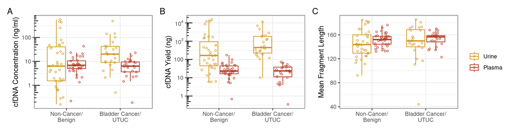

```r
ls_assay_metric <- list(
  "cfdna_concentration" = "cfDNA Concentration (ng/ml)",
  "cfdna_yield" = "cfDNA Yield (ng)",
  "analysis_filtered_fragment_lengths_stats_mean" = "Mean Fragment Length"
)

ls_fig_assay <- ls_assay_metric |>
  purrr::imap(function(metric, metric_col) {
    pl <- df_master |>
      dplyr::filter(cohort == "UCSD Training") |>
      dplyr::mutate(cancer_status = forcats::fct_recode(
        cancer_status,
        "Non-Cancer/\nBenign" = "Non-Cancer/Benign",
        "Bladder Cancer/\nUTUC" = "Bladder Cancer/UTUC"
      )) |>
      ggplot2::ggplot(ggplot2::aes_string(x = "cancer_status", y = metric_col,
                                          color = "biofluid")) +
      ggplot2::geom_boxplot(outlier.shape = NA) +
      ggplot2::geom_jitter(size = 1, shape = 1, position = ggplot2::position_jitterdodge()) +
      ggplot2::labs(x = "", y = metric) + biofluid_color
    if (metric_col %in% c("cfdna_yield", "cfdna_concentration")) {
      pl <- pl +
        ggplot2::scale_y_continuous(trans = "log10", breaks = 10^seq(0, 4),
                                    labels = c(1, 10, 100, as.expression(bquote(10^3)),
                                         as.expression(bquote(10^4)))) +
        ggplot2::annotation_logticks(sides = "l")
    }
    return(pl)
  })

patchwork::wrap_plots(ls_fig_assay, guides = "collect", nrow = 1) +
  patchwork::plot_annotation(tag_levels = 'A') +
  patchwork::plot_layout(guides = "collect")
```

```r
assay_stat <- function(df, col_by) {
  df |> gtsummary::tbl_summary(
    by = col_by,
    include = c(cfdna_concentration, cfdna_yield,
                analysis_on_binary_target_coverage_stats_mean,
                analysis_filtered_fragment_lengths_stats_mean),
    label = ls_assay_metric,
    digits = gtsummary::all_continuous() ~ 1,
    statistic = list(c(cfdna_concentration, cfdna_yield) ~
                       "{median} ({p25}, {p75}) [{min}, {max}]",
                     c(analysis_on_binary_target_coverage_stats_mean,
                       analysis_filtered_fragment_lengths_stats_mean) ~
                       "{mean} ({sd})")
  )
}
df_master |>
  dplyr::filter(cohort == "UCSD Training") |>
  dplyr::arrange(participant_id, biofluid) |>
  dplyr::mutate(.by = biofluid, id = dplyr::row_number()) |>
  dplyr::filter(.by = id, dplyr::n() == 2) |>
  assay_stat("biofluid") |>
  gtsummary::add_p(test = list(
    c(cfdna_concentration, cfdna_yield) ~ "paired.wilcox.test",
    c(analysis_on_binary_target_coverage_stats_mean,
      analysis_filtered_fragment_lengths_stats_mean) ~ "paired.t.test"),
    group = id) |>
  gtsummary::modify_caption("UCSD Training Assay Stats: by Biofluid")
```

UCSD Training Assay Stats: by Biofluid

| **Characteristic** | **urine**, N = 59<sup>1</sup> | **plasma**, N = 59<sup>1</sup> | **p-value**<sup>2</sup> |
| --- | --- | --- | --- |
| cfDNA Concentration (ng/ml) | 10.0 (2.9, 43.2) [0.2, 567.5] | 6.9 (4.1, 10.1) [0.2, 43.2] | <0.001 |
| cfDNA Yield (ng) | 305.8 (93.2, 1,513.4) [5.9, 15,322.6] | 23.2 (15.3, 41.3) [0.4, 172.7] | <0.001 |
| analysis_on_binary_target_coverage_stats_mean | 178.4 (68.5) | 185.9 (47.2) | 0.4 |
| Mean Fragment Length | 145.8 (25.7) | 152.0 (11.3) | 0.060 |

<sup>1</sup> Median (IQR) [Range]; Mean (SD)  
<sup>2</sup> Wilcoxon signed rank test with continuity correction; Paired t-test

```r
df_master |>
  dplyr::filter(cohort == "UCSD Training") |>
  gtsummary::tbl_strata(
    strata = cancer_status,
    .tbl_fun =
      ~ .x |>
      dplyr::arrange(participant_id, biofluid) |>
      dplyr::mutate(.by = biofluid, id = dplyr::row_number()) |>
      dplyr::filter(.by = id, dplyr::n() == 2) |>
      assay_stat("biofluid") |>
      gtsummary::add_p(test = list(
        c(cfdna_concentration, cfdna_yield) ~ "paired.wilcox.test",
        c(analysis_on_binary_target_coverage_stats_mean,
          analysis_filtered_fragment_lengths_stats_mean) ~ "paired.t.test"),
        group = id)
  ) |>
  gtsummary::modify_caption("UCSD Training Assay Stats: by Biofluid among Cancer/Non-cancer")
```

UCSD Training Assay Stats: by Biofluid among Cancer/Non-cancer

| **Characteristic** | **Non-Cancer/Benign** **urine**, N = 35<sup>1</sup> | **Non-Cancer/Benign** **plasma**, N = 35<sup>1</sup> | **Non-Cancer/Benign** **p-value**<sup>2</sup> | **Bladder Cancer/UTUC** **urine**, N = 24<sup>1</sup> | **Bladder Cancer/UTUC** **plasma**, N = 24<sup>1</sup> | **Bladder Cancer/UTUC** **p-value**<sup>2</sup> |
| --- | --- | --- | --- | --- | --- | --- |
| cfDNA Concentration (ng/ml) | 6.4 (1.5, 41.1) [0.2, 567.5] | 6.9 (5.1, 10.6) [0.2, 43.2] | 0.2 | 20.2 (9.1, 42.6) [0.5, 487.6] | 6.4 (3.7, 9.5) [0.2, 23.0] | <0.001 |
| cfDNA Yield (ng) | 165.3 (45.2, 1,029.8) [5.9, 15,322.6] | 23.1 (16.4, 44.6) [0.7, 172.7] | <0.001 | 447.6 (224.3, 1,829.4) [10.0, 11,459.1] | 23.7 (11.2, 38.1) [0.4, 72.5] | <0.001 |
| analysis_on_binary_target_coverage_stats_mean | 164.8 (61.1) | 191.1 (42.5) | 0.031 | 198.4 (74.9) | 178.4 (53.3) | 0.13 |
| Mean Fragment Length | 144.6 (23.0) | 151.6 (11.0) | 0.063 | 147.5 (29.6) | 152.6 (11.9) | 0.4 |

<sup>1</sup> Median (IQR) [Range]; Mean (SD)  
<sup>2</sup> Wilcoxon signed rank exact test; Paired t-test

```r
df_master |>
  urine_baseline_filter() |>
  gtsummary::tbl_strata(
    strata = cohort,
    .tbl_fun =
      ~ .x |>
      assay_stat("cancer_status") |>
      gtsummary::add_p() |>
      gtsummary::add_overall()
  ) |>
  gtsummary::modify_caption("Baseline Urine Samples Assay Stats: By Cancer Status")
```

Baseline Urine Samples Assay Stats: By Cancer Status

| **Characteristic** | **UCSD Training** **Overall**, N = 59<sup>1</sup> | **UCSD Training** **Non-Cancer/Benign**, N = 35<sup>1</sup> | **UCSD Training** **Bladder Cancer/UTUC**, N = 24<sup>1</sup> | **UCSD Training** **p-value**<sup>2</sup> | **MGB Holdout (Baseline)** **Overall**, N = 140<sup>1</sup> | **MGB Holdout (Baseline)** **Non-Cancer/Benign**, N = 70<sup>1</sup> | **MGB Holdout (Baseline)** **Bladder Cancer/UTUC**, N = 70<sup>1</sup> | **MGB Holdout (Baseline)** **p-value**<sup>3</sup> |
| --- | --- | --- | --- | --- | --- | --- | --- | --- |
| cfDNA Concentration (ng/ml) | 10.0 (2.9, 43.2) [0.2, 567.5] | 6.4 (1.5, 41.1) [0.2, 567.5] | 20.2 (9.1, 42.6) [0.5, 487.6] | 0.048 | 5.5 (3.3, 19.0) [1.0, 2,611.5] | 4.0 (2.9, 7.8) [1.3, 412.0] | 12.0 (3.9, 44.3) [1.0, 2,611.5] | <0.001 |
| cfDNA Yield (ng) | 305.8 (93.2, 1,513.4) [5.9, 15,322.6] | 165.3 (45.2, 1,029.8) [5.9, 15,322.6] | 447.6 (224.3, 1,829.4) [10.0, 11,459.1] | 0.040 | 21.0 (12.5, 75.2) [3.6, 10,446.0] | 15.0 (11.1, 29.8) [4.8, 1,441.9] | 50.7 (14.8, 171.8) [3.6, 10,446.0] | <0.001 |
| analysis_on_binary_target_coverage_stats_mean | 178.4 (68.5) | 164.8 (61.1) | 198.4 (74.9) | 0.056 | 101.5 (48.4) | 85.7 (38.7) | 117.3 (52.1) | <0.001 |
| Mean Fragment Length | 145.8 (25.7) | 144.6 (23.0) | 147.5 (29.6) | 0.3 | 140.9 (12.8) | 137.5 (10.8) | 144.3 (13.7) | 0.002 |

<sup>1</sup> Median (IQR) [Range]; Mean (SD)  
<sup>2</sup> Wilcoxon rank sum test; Wilcoxon rank sum exact test  
<sup>3</sup> Wilcoxon rank sum test

# TMeF of Baseline Samples

UCSD baseline samples (training)

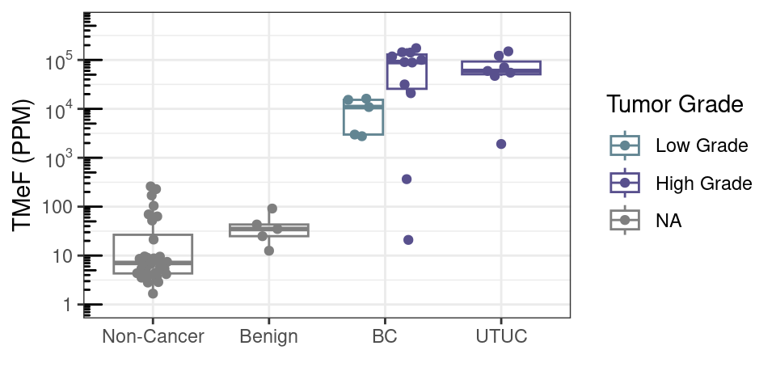

```r
format_tmef_plt <- list(
  ggplot2::labs(x = "", y = "TMeF (PPM)"),
  ggplot2::scale_y_continuous(trans = "log10", limits = c(1, 5* 10^5), breaks = 10^seq(0, 5),
                              labels = c("1", "10", "100", as.expression(bquote(10^3)),
                                         as.expression(bquote(10^4)),
                                         as.expression(bquote(10^5)))),
  ggplot2::annotation_logticks(sides = "l")
)
df_evaluable |>
  urine_training_filter() |>
  ggplot2::ggplot(ggplot2::aes(x = cancer_type, y = median_tmef,
                               color = grade, fill = grade)) +
  ggplot2::geom_boxplot(alpha = 0, outlier.alpha = 0) +
  ggbeeswarm::geom_quasirandom(dodge.width = 0.8, shape = 21) +
  format_tmef_plt + grade_color + grade_fill
```

```r
for (c in c("Benign", "BC", "UTUC")) {
  df_evaluable |>
    urine_training_filter() |>
    dplyr::filter(cancer_type %in% c("Non-Cancer", c)) |>
    dplyr::mutate(cancer_type = forcats::fct_drop(cancer_type)) |>
    gtsummary::tbl_summary(
      by = cancer_type,
      include = c(median_tmef),
      label = list(median_tmef = "TMeF (PPM)"),
      type = list(median_tmef ~ "continuous")
    ) |>
    gtsummary::add_p() |>
    print()
}
df_evaluable |>
  urine_training_filter() |>
  dplyr::filter(cancer_type %in% c("BC")) |>
  gtsummary::tbl_summary(
    by = grade,
    include = c(median_tmef),
    label = list(median_tmef = "TMeF (PPM)"),
    type = list(median_tmef ~ "continuous")
  ) |>
  gtsummary::add_p()
```

[output not shown]

| **Characteristic** | **Low Grade**, N = 5<sup>1</sup> | **High Grade**, N = 11<sup>1</sup> | **p-value**<sup>2</sup> |
| --- | --- | --- | --- |
| TMeF (PPM) | 10,890 (2,979, 15,295) | 90,369 (26,236, 129,723) | 0.052 |

<sup>1</sup> Median (IQR)  
<sup>2</sup> Wilcoxon rank sum exact test

# Baseline Sensitivity/Specificity

```r
summarise_sens_spec <- function(df_sample) {
  n_tp <- sum(df_sample$cancer_status == "Bladder Cancer/UTUC" & df_sample$cancer_detected)
  n_fp <- sum(df_sample$cancer_status == "Non-Cancer/Benign" & df_sample$cancer_detected)
  n_fn <- sum(df_sample$cancer_status == "Bladder Cancer/UTUC" & !df_sample$cancer_detected)
  n_tn <- sum(df_sample$cancer_status == "Non-Cancer/Benign" & !df_sample$cancer_detected)
  ls_sensitivity <- format_pct_stat(n_tp, n_tp + n_fn)
  ls_specificity <- format_pct_stat(n_tn, n_tn + n_fp)
  data.frame(sensitivity = ls_sensitivity$pct, sensitivity_lci = ls_sensitivity$pct_lci,
             sensitivity_uci = ls_sensitivity$pct_uci,
             sensitivity_label = ls_sensitivity$label,
             sensitivity_label_ci = ls_sensitivity$label_ci,
             specificity = ls_specificity$pct, specificity_lci = ls_specificity$pct_lci,
             specificity_uci = ls_specificity$pct_uci,
             specificity_label = ls_specificity$label,
             specificity_label_ci = ls_specificity$label_ci)
}

df_performance <- dplyr::bind_rows(
  df_baseline |> dplyr::group_by(biofluid, cohort) |>
    dplyr::group_modify(~summarise_sens_spec(.x), .keep = TRUE) |>
    dplyr::mutate(cancer_type = "All UC"),
  df_baseline |> dplyr::filter(cancer_type %in% c("BC", "UTUC")) |>
    dplyr::mutate(cancer_type = as.character(cancer_type)) |>
    dplyr::group_by(biofluid, cohort, cancer_type) |>
    dplyr::group_modify(~summarise_sens_spec(.x), .keep = TRUE),
  df_baseline |> dplyr::filter(cancer_type %in% c("BC", "UTUC")) |>
    dplyr::group_by(biofluid, cohort, grade) |>
    dplyr::group_modify(~summarise_sens_spec(.x), .keep = TRUE) |>
    dplyr::mutate(cancer_type = "All UC"),
  df_baseline |> dplyr::filter(cancer_type %in% c("BC", "UTUC")) |>
    dplyr::mutate(cancer_type = as.character(cancer_type)) |>
    dplyr::group_by(biofluid, cohort, cancer_type, grade) |>
    dplyr::group_modify(~summarise_sens_spec(.x), .keep = TRUE)
) |> dplyr::ungroup()

df_performance |>
  dplyr::arrange(cohort, cancer_type, grade, biofluid) |>
  dplyr::select(biofluid, cohort, cancer_type, grade,
                sensitivity_label_ci, specificity_label_ci) |>
  gt::gt("Performance in baseline samples")
```

| biofluid | cohort | cancer_type | grade | sensitivity_label_ci | specificity_label_ci |
| --- | --- | --- | --- | --- | --- |
| urine | UCSD Training | All UC | Low Grade | 100% (5/5) [57%-100%] | NA (0/0) [NA-NA] |
| plasma | UCSD Training | All UC | Low Grade | 20% (1/5) [4%-62%] | NA (0/0) [NA-NA] |
| urine | UCSD Training | All UC | High Grade | 94% (17/18) [74%-99%] | NA (0/0) [NA-NA] |
| plasma | UCSD Training | All UC | High Grade | 26% (5/19) [12%-49%] | NA (0/0) [NA-NA] |
| urine | UCSD Training | All UC | NA | 96% (22/23) [79%-99%] | 100% (33/33) [90%-100%] |
| plasma | UCSD Training | All UC | NA | 25% (6/24) [12%-45%] | 100% (35/35) [90%-100%] |
| urine | UCSD Training | BC | Low Grade | 100% (5/5) [57%-100%] | NA (0/0) [NA-NA] |
| plasma | UCSD Training | BC | Low Grade | 20% (1/5) [4%-62%] | NA (0/0) [NA-NA] |
| urine | UCSD Training | BC | High Grade | 91% (10/11) [62%-98%] | NA (0/0) [NA-NA] |
| plasma | UCSD Training | BC | High Grade | 8% (1/12) [1%-35%] | NA (0/0) [NA-NA] |
| urine | UCSD Training | BC | NA | 94% (15/16) [72%-99%] | NA (0/0) [NA-NA] |
| plasma | UCSD Training | BC | NA | 12% (2/17) [3%-34%] | NA (0/0) [NA-NA] |
| urine | UCSD Training | UTUC | High Grade | 100% (7/7) [65%-100%] | NA (0/0) [NA-NA] |
| plasma | UCSD Training | UTUC | High Grade | 57% (4/7) [25%-84%] | NA (0/0) [NA-NA] |
| urine | UCSD Training | UTUC | NA | 100% (7/7) [65%-100%] | NA (0/0) [NA-NA] |
| plasma | UCSD Training | UTUC | NA | 57% (4/7) [25%-84%] | NA (0/0) [NA-NA] |
| urine | MGB Holdout (Baseline) | All UC | Low Grade | 67% (22/33) [50%-80%] | NA (0/0) [NA-NA] |
| urine | MGB Holdout (Baseline) | All UC | High Grade | 100% (35/35) [90%-100%] | NA (0/0) [NA-NA] |
| urine | MGB Holdout (Baseline) | All UC | NA | 84% (57/68) [73%-91%] | 97% (64/66) [90%-99%] |
| urine | MGB Holdout (Baseline) | BC | Low Grade | 61% (14/23) [41%-78%] | NA (0/0) [NA-NA] |
| urine | MGB Holdout (Baseline) | BC | High Grade | 100% (25/25) [87%-100%] | NA (0/0) [NA-NA] |
| urine | MGB Holdout (Baseline) | BC | NA | 81% (39/48) [68%-90%] | NA (0/0) [NA-NA] |
| urine | MGB Holdout (Baseline) | UTUC | Low Grade | 80% (8/10) [49%-94%] | NA (0/0) [NA-NA] |
| urine | MGB Holdout (Baseline) | UTUC | High Grade | 100% (10/10) [72%-100%] | NA (0/0) [NA-NA] |
| urine | MGB Holdout (Baseline) | UTUC | NA | 90% (18/20) [70%-97%] | NA (0/0) [NA-NA] |

```r
# Plot sensitivity/specificity
format_sens_plt <- list(
  ggplot2::geom_point(size = 2, position = ggplot2::position_dodge(width = 0.5)),
  ggplot2::geom_errorbar(width = 0.2, position = ggplot2::position_dodge(width = 0.5)),
  ggplot2::geom_text(ggplot2::aes(y = 1.1), position = ggplot2::position_dodge(width = 0.5),
                     angle = 45, vjust = 0, hjust = 0, size = 3),
  ggplot2::scale_y_continuous(breaks = seq(0, 1, 0.2), labels = scales::percent),
  ggplot2::labs(y = "Sensitivity", x = ""),
  ggplot2::coord_cartesian(ylim = c(0, 1), clip = "off"),
  ggplot2::theme(plot.margin = ggplot2::margin(50, 20, 0, 0)),
  cohort_color, cohort_fill,
  ggplot2::theme(legend.position = "none")
)

# Specificity
plt_spec <- df_performance |>
  dplyr::filter(cancer_type == "All UC", !is.na(specificity), biofluid == "urine") |>
  ggplot2::ggplot(ggplot2::aes(x = cohort, y = specificity, ymin = specificity_lci,
                               ymax = specificity_uci, label = specificity_label,
                               color = cohort, fill = cohort)) +
  format_sens_plt +
  ggplot2::labs(y = "Specificity")

# Sensitivity by cancer type
plt_sens_cancer_type <- df_performance |>
  dplyr::filter(cancer_type != "All UC", biofluid == "urine") |>
  dplyr::mutate(cancer_type = factor(cancer_type, levels = c("BC", "UTUC"))) |>
  dplyr::filter(is.na(grade)) |>
  ggplot2::ggplot(ggplot2::aes(x = cancer_type, y = sensitivity, ymin = sensitivity_lci,
                               ymax = sensitivity_uci, label = sensitivity_label,
                               color = cohort, fill = cohort)) +
  format_sens_plt

# Sensitivity by grade
plt_sens_grade <- df_performance |>
  dplyr::filter(!is.na(grade), cancer_type != "All UC", biofluid == "urine") |>
  dplyr::mutate(cancer_type = factor(cancer_type, levels = c("BC", "UTUC"))) |>
  ggplot2::ggplot(ggplot2::aes(x = cancer_type, y = sensitivity, ymin = sensitivity_lci,
                               ymax = sensitivity_uci, label = sensitivity_label,
                               color = cohort, fill = cohort)) +
  format_sens_plt +
  ggplot2::facet_wrap("grade", strip.position = "right") +
  ggplot2::theme(legend.position = "right")
```

```r
plt_tmef_holdout <- df_baseline |>
  dplyr::filter(cohort == "MGB Holdout (Baseline)") |>
  ggplot2::ggplot(ggplot2::aes(x = cancer_type, y = median_tmef,
                               color = grade, fill = grade)) +
  ggbeeswarm::geom_quasirandom(dodge.width = 0.8, size = 1) +
  ggplot2::geom_boxplot(alpha = 0, outlier.alpha = 0) +
  ggplot2::facet_wrap("cohort") +
  format_tmef_plt + grade_color + grade_fill  +
  ggplot2::guides(shape = "none") +
  ggplot2::theme(legend.position = c(0.85, 0.2))
```

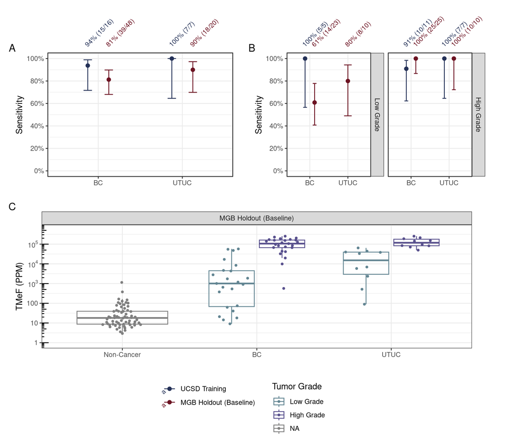

```r
ggplot2::theme_set(ggplot2::theme_bw() + set_font + ggplot2::theme(legend.position = "bottom"))
patchwork::free(plt_sens_cancer_type, side = "l") +
  patchwork::free(plt_sens_grade, side = "l") +
  patchwork::free(plt_tmef_holdout, side = "l") +
  patchwork::guide_area() +
  patchwork::plot_annotation(tag_levels = 'A') +
  patchwork::plot_layout(guides = "collect", design = c(
    patchwork::area(t = 1, b = 4, l = 1, r = 5),
    patchwork::area(t = 1, b = 4, l = 6, r = 10),
    patchwork::area(t = 5, b = 8, l = 1, r = 10),
    patchwork::area(t = 9, b = 10, l = 1, r = 10)
  ))
```

# UCSD Surveillance

## Performance in predicting recurrence

```r
df_surv |>
  gtsummary::tbl_summary(
    by = recurrence_status_bsl,
    include = c(cancer_detected, cysto_result, cytology_result, path_bsl)
  )
```

| **Characteristic** | **Recurrence+**, N = 8<sup>1</sup> | **Recurrence-**, N = 83<sup>1</sup> |
| --- | --- | --- |
| cancer_detected | 7 (88%) | 29 (35%) |
| cysto_result |  |  |
| No Suspicious Lesion | 0 (0%) | 76 (92%) |
| Suspicious Lesion | 8 (100%) | 7 (8.4%) |
| cytology_result |  |  |
| AUC | 4 (57%) | 10 (13%) |
| HGUC | 2 (29%) | 0 (0%) |
| Negative | 1 (14%) | 69 (87%) |
| Unknown | 1 | 4 |
| path_bsl |  |  |
| benign | 0 (0%) | 7 (100%) |
| Ta, high grade | 1 (14%) | 0 (0%) |
| Ta, low grade | 5 (71%) | 0 (0%) |
| Tis, high grade | 1 (14%) | 0 (0%) |
| Unknown | 1 | 76 |

<sup>1</sup> n (%)

```r
format_ppv_npv <- function(ci_result, caption = "PPV / NPV") {
  data.frame(
    Metric = c("PPV", "NPV"),
    Estimate = scales::percent(c(ci_result$ppv["ppv_est"], ci_result$npv["npv_est"]),
                               accuracy = 0.1),
    `95% CI` = c(
      sprintf("[%s, %s]",
              scales::percent(ci_result$ppv["ppv_l"], accuracy = 0.1),
              scales::percent(ci_result$ppv["ppv_u"], accuracy = 0.1)),
      sprintf("[%s, %s]",
              scales::percent(ci_result$npv["npv_l"], accuracy = 0.1),
              scales::percent(ci_result$npv["npv_u"], accuracy = 0.1))
    ), check.names = FALSE
  ) |> gt::gt(caption = caption)
}

CIfinder::ppv_npv_ci(
  sum(df_surv$recurrence_status_bsl == "Recurrence+" & df_surv$cancer_detected),
  sum(df_surv$recurrence_status_bsl == "Recurrence+"),
  sum(df_surv$recurrence_status_bsl == "Recurrence-" & (!df_surv$cancer_detected)),
  sum(df_surv$recurrence_status_bsl == "Recurrence-"),
  sum(df_surv$recurrence_status_bsl == "Recurrence+") / nrow(df_surv)) |>
  format_ppv_npv("Surveillance: PPV / NPV")
```

Surveillance: PPV / NPV

| Metric | Estimate | 95% CI |
| --- | --- | --- |
| PPV | 19.4% | [12.3%, 26.0%] |
| NPV | 98.2% | [93.4%, 99.9%] |

## Tileplot

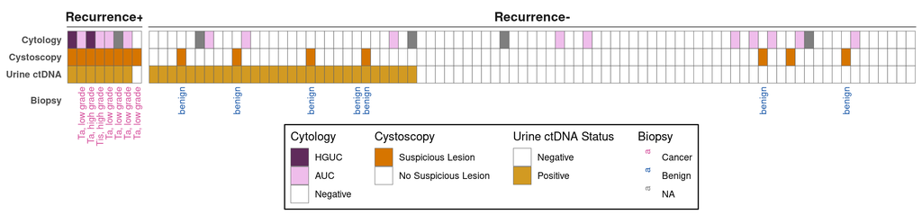

```r
df_surv |>
  dplyr::arrange(desc(cancer_detected)) |>
  dplyr::mutate(id = forcats::fct_inorder(participant_id),
                recurrence_status_bsl = factor(recurrence_status_bsl,
                                               levels = c("Recurrence+", "Recurrence-")),
                biopsy_benign_bsl = path_bsl == "benign") |>
  ggplot2::ggplot() +
  # Cancer detection tile
  ggplot2::geom_tile(ggplot2::aes(x = id, y = 1, fill = cancer_detected), color = "gray40") +
  fill_urine_ctdna +
  ggnewscale::new_scale_fill() +
  # Other test
  ggplot2::geom_tile(ggplot2::aes(x = id, y = 2, fill = cysto_result), color = "gray40") +
    ggplot2::scale_fill_manual(
      "Cystoscopy", breaks = c("Suspicious Lesion", "No Suspicious Lesion"),
      values = c("Suspicious Lesion" = "#D67500", "No Suspicious Lesion" = "white"),
      guide = ggplot2::guide_legend(order = 2)
  ) +
  ggnewscale::new_scale_fill() +
  ggplot2::geom_tile(ggplot2::aes(x = id, y = 3, fill = cytology_result), color = "gray40") +
  ggplot2::scale_fill_manual(
    "Cytology", breaks = c("HGUC", "Suspicious", "AUC", "Negative"),
    values = c("HGUC" = "#602B5B", "Suspicious" = "#B68CB8", "AUC" = "#EFBDEB",
               "Negative" = "white"),
      guide = ggplot2::guide_legend(order = 1)
  ) +
  ggplot2::geom_text(ggplot2::aes(x = id, y = 0.3, label = path_bsl, color = biopsy_benign_bsl),
                     angle = 90, vjust = 0.5, hjust = 1, size = 3) +
  ggplot2::scale_color_manual("Biopsy", values = c("#D54F9C", "#1756A7"),
                              labels = c("Cancer", "Benign"),
                              guide = ggplot2::guide_legend(order = 3)) +
  ggplot2::scale_y_continuous(breaks = c(3, 2, 1, -0.5),
                              labels = c("Cytology", "Cystoscopy", "Urine ctDNA", "Biopsy")) +
  ggplot2::facet_grid(cols = ggplot2::vars(recurrence_status_bsl),
                      scales = "free", space = "free") +
  ggplot2::coord_cartesian(clip = "off", ylim = c(3.5, -1)) +
  ggplot2::theme_minimal() +
  ggplot2::theme(axis.text.x = ggplot2::element_blank(), axis.ticks.x = ggplot2::element_blank(),
                 axis.title.x = ggplot2::element_blank(), axis.ticks.y = ggplot2::element_blank(),
                 axis.text.y = ggplot2::element_text(face = "bold"),
                 axis.title.y = ggplot2::element_blank(),
                 panel.grid = ggplot2::element_blank(),
                 legend.position = "bottom", legend.direction = "vertical",
                 legend.box.background = ggplot2::element_rect(color = "black", linewidth = 0.5),
                 strip.background = ggh4x::element_part_rect(side = "b", color = "black"),
                 strip.placement = "outside",
                 strip.text = ggplot2::element_text(size = 12, face = "bold"))
```

## Survival Plot

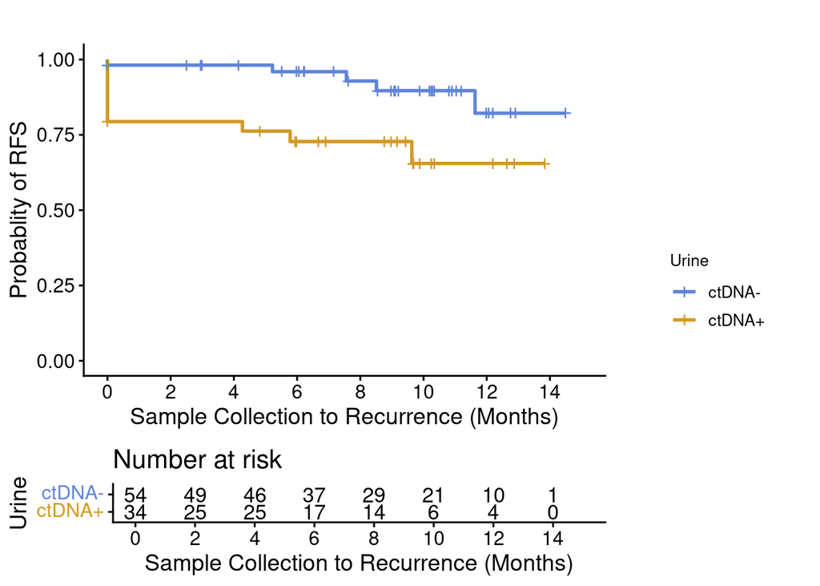

```r
fit <- survminer::surv_fit(survival::Surv(rfs_interval, rfs_status) ~ cancer_detected,
                           data =  df_surv)
survminer::ggsurvplot(fit,
                      xlab = "Sample Collection to Recurrence (Months)",
                      ylab = "Probablity of RFS",
                      risk.table = TRUE, combine = TRUE,
                      break.time.by = 2,
                      pval.size = 5,
                      legend ='right', legend.title = "Urine",
                      legend.labs = c("ctDNA-", "ctDNA+"),
                      palette = c("#6184D8", "#D29A22"),
                      title = "")
```

# Pre-Surgery pCR Analysis

## Patient Characteristic

```r
df_pcr |>
  dplyr::mutate_at(c("tstage", "tstage_surgery"), forcats::fct_drop)  |>
  dplyr::mutate(cancer_type = as.character(cancer_type)) |>
  gtsummary::tbl_strata(
    strata = biobank,
    .tbl_fun = ~ .x |>
      gtsummary::tbl_summary(
        by = cancer_type,
        include = c(sex, age, had_neoadjuvant_therapy, pcr_status, tstage, tstage_surgery),
        label = list(sex = "Sex", age = "Age",
                     had_neoadjuvant_therapy = "Received NAC",
                     pcr_status = "pCR Status",
                     tstage = "T stage at Diagnosis",
                     tstage_surgery = "T Stage at Surgery")
      )
  ) |>
  gtsummary::modify_caption("**Patient Characteristic of Pre-Surgery Sample Cohort**")
```

**Patient Characteristic of Pre-Surgery Sample Cohort**

| **Characteristic** | **UCSD** **MIBC**, N = 11<sup>1</sup> | **UCSD** **UTUC**, N = 6<sup>1</sup> | **MGB** **MIBC**, N = 57<sup>1</sup> |
| --- | --- | --- | --- |
| Sex |  |  |  |
| Female | 1 (9.1%) | 2 (33%) | 17 (30%) |
| Male | 10 (91%) | 4 (67%) | 40 (70%) |
| Age | 72.0 (67.0, 77.0) | 76.0 (76.0, 78.3) | 66 (58, 73) |
| Received NAC | 4 (36%) | 0 (0%) | 57 (100%) |
| pCR Status |  |  |  |
| No-pCR | 7 (64%) | 6 (100%) | 47 (82%) |
| pCR | 4 (36%) | 0 (0%) | 10 (18%) |
| T stage at Diagnosis |  |  |  |
| Tis | 1 (9.1%) | 0 (0%) | 0 (0%) |
| Ta | 0 (0%) | 3 (50%) | 2 (3.6%) |
| T1 | 0 (0%) | 2 (33%) | 10 (18%) |
| T2 | 8 (73%) | 0 (0%) | 43 (77%) |
| T3 | 1 (9.1%) | 1 (17%) | 1 (1.8%) |
| T4 | 1 (9.1%) | 0 (0%) | 0 (0%) |
| Unknown |  |  | 1 |
| T Stage at Surgery |  |  |  |
| T0 | 4 (36%) | 0 (0%) | 11 (19%) |
| Tis | 2 (18%) | 0 (0%) | 6 (11%) |
| Ta | 0 (0%) | 2 (33%) | 1 (1.8%) |
| T1 | 2 (18%) | 1 (17%) | 5 (8.8%) |
| T2 | 0 (0%) | 1 (17%) | 6 (11%) |
| T3 | 0 (0%) | 1 (17%) | 18 (32%) |
| T3a | 1 (9.1%) | 1 (17%) | 0 (0%) |
| T3b | 1 (9.1%) | 0 (0%) | 0 (0%) |
| T4 | 0 (0%) | 0 (0%) | 10 (18%) |
| T4a | 1 (9.1%) | 0 (0%) | 0 (0%) |

<sup>1</sup> n (%); Median (IQR)

## Performance in predicting pCR

```r
c("Overall", "UCSD", "MGB") |>
  purrr::map(function(subset) {
    c("Urine", "Plasma", "Urine|Plasma") |>
      purrr::map(function(biofluid) {
        df_perf_eval <- df_pcr
        if (subset != "Overall") {
          df_perf_eval <- df_pcr |>
            dplyr::filter(biobank == subset)
        }
        binary_col <- ifelse(biofluid == "Urine", "cancer_detected_urine",
                             ifelse(biofluid == "Plasma", "cancer_detected_plasma",
                                    "cancer_detected_urine_or_plasma"))
        df_perf_eval |>
          summarise_pcr_perf(binary_col = binary_col) |>
          dplyr::mutate(Cohort = subset, Biofluid = biofluid)
      }) |>
      dplyr::bind_rows()
  }) |>
  dplyr::bind_rows() |>
  dplyr::select(Cohort, Biofluid, Sensitivity:NPV) |>
  gt::gt()
```

| Cohort | Biofluid | Sensitivity | Specificity | PPV | NPV |
| --- | --- | --- | --- | --- | --- |
| Overall | Urine | 86% (51/59) [75%-93%] | 93% (13/14) [69%-99%] | 98% (51/52) [90%-100%] | 62% (13/21) [41%-79%] |
| Overall | Plasma | 42% (25/60) [30%-54%] | 93% (13/14) [69%-99%] | 96% (25/26) [81%-99%] | 27% (13/48) [17%-41%] |
| Overall | Urine\|Plasma | 93% (56/60) [84%-97%] | 86% (12/14) [60%-96%] | 97% (56/58) [88%-99%] | 75% (12/16) [51%-90%] |
| UCSD | Urine | 85% (11/13) [58%-96%] | 100% (4/4) [51%-100%] | 100% (11/11) [74%-100%] | 67% (4/6) [30%-90%] |
| UCSD | Plasma | 46% (6/13) [23%-71%] | 75% (3/4) [30%-95%] | 86% (6/7) [49%-97%] | 30% (3/10) [11%-60%] |
| UCSD | Urine\|Plasma | 92% (12/13) [67%-99%] | 75% (3/4) [30%-95%] | 92% (12/13) [67%-99%] | 75% (3/4) [30%-95%] |
| MGB | Urine | 87% (40/46) [74%-94%] | 90% (9/10) [60%-98%] | 98% (40/41) [87%-100%] | 60% (9/15) [36%-80%] |
| MGB | Plasma | 40% (19/47) [28%-55%] | 100% (10/10) [72%-100%] | 100% (19/19) [83%-100%] | 26% (10/38) [15%-42%] |
| MGB | Urine\|Plasma | 94% (44/47) [83%-98%] | 90% (9/10) [60%-98%] | 98% (44/45) [88%-100%] | 75% (9/12) [47%-91%] |

```r
df_pcr_mgb <- df_pcr |>
  dplyr::filter(biobank == "MGB")
CIfinder::ppv_npv_ci(
  sum(df_pcr_mgb$pcr_status == "No-pCR" & df_pcr_mgb$cancer_detected_urine_or_plasma),
  sum(df_pcr_mgb$pcr_status == "No-pCR"),
  sum(df_pcr_mgb$pcr_status == "pCR" & (!df_pcr_mgb$cancer_detected_urine_or_plasma)),
  sum(df_pcr_mgb$pcr_status == "pCR"),
  1 - 0.36) |>
  format_ppv_npv("MGB Pre-Surgery: PPV / NPV (assuming 36% pCR rate)")
```

MGB Pre-Surgery: PPV / NPV (assuming 36% pCR rate)

| Metric | Estimate | 95% CI |
| --- | --- | --- |
| PPV | 94.3% | [80.9%, 99.6%] |
| NPV | 88.8% | [74.9%, 96.8%] |

## Tileplot

```r
tile_plot_pcr_analysis <- function(df) {
  df |>
    dplyr::arrange(pcr_status, tstage_surgery, tnm_surgery) |>
    dplyr::mutate(id = forcats::fct_inorder(participant_id),
                  tnm_surgery = ifelse(pcr_status == "pCR", NA_character_, tnm_surgery)) |>
    ggplot2::ggplot() +
    # Cancer type tile
    ggplot2::geom_tile(ggplot2::aes(x = id, y = 4.5, fill = cancer_type), height = 0.5) +
    ggplot2::scale_fill_manual("Cancer Type", values = c("MIBC" = "#D67500", "UTUC" = "#85B05B"),
                               guide = ggplot2::guide_legend(order = 1)) +
    ggnewscale::new_scale_fill() +
    # Cancer type tile
    ggplot2::geom_tile(ggplot2::aes(x = id, y = 4, fill = had_neoadjuvant_therapy), height = 0.5) +
    ggplot2::scale_fill_manual("Neoadjuvant Chemo", guide = ggplot2::guide_legend(order = 2),
                               values = c(`TRUE` = "#602B5B", `FALSE` = "#B68CB8"),
                               labels = c(`TRUE` = "Received NAC", `FALSE` = "No NAC")) +
    ggnewscale::new_scale_fill() +
    # urine tiles
    ggplot2::geom_tile(ggplot2::aes(x = id, y = 3, fill = cancer_detected_urine),
                       color = "gray40") +
    fill_urine_ctdna +
    ggnewscale::new_scale_fill() +
    # plasma ctDNA status
    ggplot2::geom_tile(ggplot2::aes(x = id, y = 2, fill = cancer_detected_plasma),
                       color = "gray40") +
    fill_plasma_ctdna +
    # Path stage text
    ggplot2::geom_text(ggplot2::aes(x = id, y = 1.3, label = tnm_surgery),
                       angle = 90, vjust = 0.5, hjust = 1, size = 2.5) +
    ggplot2::scale_y_continuous(breaks = c(1, 2, 3, 4, 4.5),
                                labels = c("Path Stage (RC)", "Plasma ctDNA", "Urine ctDNA",
                                           "Received NAC", "Cancer Type")) +
    ggplot2::coord_cartesian(clip = "off", ylim = c(5, 0)) +
    ggplot2::facet_grid(cols = ggplot2::vars(pcr_status), scales = "free", space = "free") +
    ggplot2::theme_minimal() +
    ggplot2::theme(axis.text.x = ggplot2::element_blank(), axis.ticks.x = ggplot2::element_blank(),
                   axis.title.x = ggplot2::element_blank(), axis.ticks.y = ggplot2::element_blank(),
                   axis.text.y = ggplot2::element_text(face = "bold"),
                   axis.title.y = ggplot2::element_blank(),
                   panel.grid = ggplot2::element_blank(),
                   legend.position = "bottom", legend.direction = "vertical",
                   legend.box.background = ggplot2::element_rect(color = "black", linewidth = 0.5),
                   strip.background = ggh4x::element_part_rect(side = "b", color = "black"),
                   strip.placement = "outside",
                   strip.text = ggplot2::element_text(size = 12, face = "bold"))
}
```

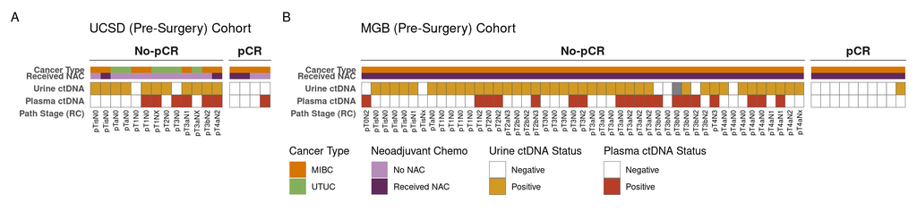

```r
(df_pcr |>
   dplyr::filter(biobank == "UCSD") |>
   tile_plot_pcr_analysis() +
   ggplot2::labs(title = "UCSD (Pre-Surgery) Cohort") |
 df_pcr |>
   dplyr::filter(biobank == "MGB") |>
   tile_plot_pcr_analysis() + ggplot2::theme(legend.position = "none") +
   ggplot2::labs(title = "MGB (Pre-Surgery) Cohort")) +
  patchwork::plot_layout(guides = "collect", widths = c(1, 3)) +
  patchwork::plot_annotation(tag_levels = 'A')
```

# ROC

```r
# Helper: compute ROC curve points from a data.frame with response & cancer_score
compute_roc_curves <- function(df, group_col = "cohort") {
  df |>
    dplyr::group_by(.data[[group_col]]) |>
    dplyr::group_map(~{
      roc_obj <- pROC::roc(response = .x$response, predictor = .x$cancer_score, direction = "<")
      data.frame(cohort = .y[[group_col]][1], tpr = roc_obj$sensitivities,
                 fpr = 1 - roc_obj$specificities)
    }) |>
    dplyr::bind_rows()
}

# Helper: compute AUC with CI from a data.frame with response & cancer_score
compute_auc_table <- function(df, group_col = "cohort") {
  df |>
    dplyr::group_by(.data[[group_col]]) |>
    dplyr::summarise(roc_obj = list(pROC::roc(response = response,
                                              predictor = cancer_score, direction = "<")),
                     N = dplyr::n(),
                     N_actual_positive = sum(response),
                     N_actual_negative = sum(!response),
                     .groups = "drop") |>
    dplyr::rename(cohort = !!group_col) |>
    dplyr::mutate(auc = purrr::map_dbl(roc_obj, ~as.numeric(pROC::auc(.x))),
                  auc_lci = purrr::map_dbl(roc_obj, ~as.numeric(pROC::ci.auc(.x))[1]),
                  auc_uci = purrr::map_dbl(roc_obj, ~as.numeric(pROC::ci.auc(.x))[3]),
                  label = sprintf("AUC = %.2f [%.2f-%.2f]", auc, auc_lci, auc_uci)) |>
    dplyr::select(-roc_obj)
}

# --- Baseline ROC (cancer detection) ---
df_roc_baseline_input <- df_baseline |>
  dplyr::filter(biofluid == "urine", cohort != "UCSD Training") |>
  dplyr::mutate(response = cancer_status == "Bladder Cancer/UTUC")

df_roc <- compute_roc_curves(df_roc_baseline_input)
df_auc <- compute_auc_table(df_roc_baseline_input) |>
  dplyr::mutate(x_pos = 0.3, y_pos = 0.15)

# --- Surveillance ROC (recurrence detection) ---
df_roc_surv_input <- df_surv |>
  dplyr::filter(!is.na(cancer_score), !is.na(recurrence_status_bsl)) |>
  dplyr::mutate(response = recurrence_status_bsl == "Recurrence+",
                cohort = "UCSD Holdout (Surveillance)")

df_roc_surv <- compute_roc_curves(df_roc_surv_input)
df_auc_surv <- compute_auc_table(df_roc_surv_input) |>
  dplyr::mutate(x_pos = 0.3, y_pos = 0.15)

# --- Pre-Surgery ROC (residual cancer / no-pCR detection, urine) ---
df_roc_pcr_input <- df_pcr |>
  dplyr::filter(!is.na(cancer_score_urine), !is.na(pcr_status)) |>
  dplyr::mutate(response = pcr_status == "No-pCR",
                cohort = "Pre-Surgery (Urine)",
                cancer_score = cancer_score_urine)

df_roc_pcr <- compute_roc_curves(df_roc_pcr_input)
df_auc_pcr <- compute_auc_table(df_roc_pcr_input) |>
  dplyr::mutate(x_pos = 0.3, y_pos = 0.15)
```

```r
dplyr::bind_rows(df_auc, df_auc_surv, df_auc_pcr) |>
  dplyr::select(cohort, N_actual_positive, N_actual_negative, AUC = label) |>
  gt::gt("AUC in each cohort")
```

| cohort | N_actual_positive | N_actual_negative | AUC |
| --- | --- | --- | --- |
| MGB Holdout (Baseline) | 68 | 66 | AUC = 0.94 [0.90-0.98] |
| UCSD Holdout (Surveillance) | 8 | 83 | AUC = 0.88 [0.75-1.00] |
| Pre-Surgery (Urine) | 59 | 14 | AUC = 0.91 [0.84-0.98] |

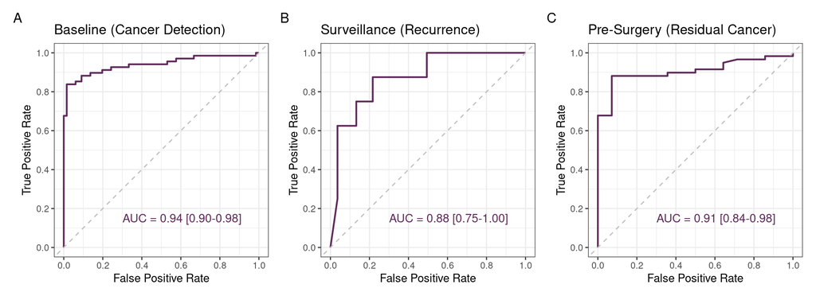

```r
roc_base_layers <- list(
  ggplot2::geom_abline(slope = 1, intercept = 0, linetype = "dashed", color = "gray"),
  ggplot2::scale_x_continuous(breaks = seq(0, 1, 0.2)),
  ggplot2::scale_y_continuous(breaks = seq(0, 1, 0.2)),
  ggplot2::coord_fixed(ratio = 1),
  ggplot2::labs(x = "False Positive Rate", y = "True Positive Rate"),
  ggplot2::theme(legend.position = "inside", legend.position.inside = c(0.95, 0.5),
                 legend.justification = c(1, 0),
                 legend.background = ggplot2::element_rect(fill = "white", color = NA))
)

plt_roc_baseline <- df_roc |>
  dplyr::arrange(cohort, fpr, tpr) |>
  ggplot2::ggplot(ggplot2::aes(x = fpr, y = tpr, color = cohort)) +
  ggplot2::geom_line(linewidth = 0.8, color = "#602B5B") +
  ggplot2::geom_text(data = df_auc, ggplot2::aes(x = x_pos, y = y_pos, label = label),
                     hjust = 0, size = 4, show.legend = FALSE, color = "#602B5B") +
  roc_base_layers + cohort_color +
  ggplot2::ggtitle("Baseline (Cancer Detection)")

plt_roc_surv <- df_roc_surv |>
  dplyr::arrange(cohort, fpr, tpr) |>
  ggplot2::ggplot(ggplot2::aes(x = fpr, y = tpr)) +
  ggplot2::geom_line(linewidth = 0.8, color = "#602B5B") +
  ggplot2::geom_text(data = df_auc_surv, ggplot2::aes(x = x_pos, y = y_pos, label = label),
                     hjust = 0, size = 4, color = "#602B5B") +
  roc_base_layers +
  ggplot2::ggtitle("Surveillance (Recurrence)")

plt_roc_pcr <- df_roc_pcr |>
  dplyr::arrange(cohort, fpr, tpr) |>
  ggplot2::ggplot(ggplot2::aes(x = fpr, y = tpr)) +
  ggplot2::geom_line(linewidth = 0.8, color = "#602B5B") +
  ggplot2::geom_text(data = df_auc_pcr, ggplot2::aes(x = x_pos, y = y_pos, label = label),
                     hjust = 0, size = 4, color = "#602B5B") +
  roc_base_layers +
  ggplot2::ggtitle("Pre-Surgery (Residual Cancer)")

plt_roc_baseline + plt_roc_surv + plt_roc_pcr +
  patchwork::plot_annotation(tag_levels = 'A') +
  patchwork::plot_layout(nrow = 1)
```

# Reproducibility

## Parameters

```r
data.frame(parameter = names(params), value = as.character(params)) |>
  gt::gt(caption = "Report parameters")
```

Report parameters

| parameter | value |
| --- | --- |
| rmd_title | Urine Manuscript Analysis |
| rmd_subtitle | complete |
| rmd_author | Yinjie Gao |
| output_dir | ~ |
| data_file | urine_cfdna_manuscript_data_20261014.xlsx |
| figure_format | png |

**R version 4.3.2 (2023-10-31)**

**Platform:** x86_64-pc-linux-gnu (64-bit)

**locale:** *LC_CTYPE=C.UTF-8*, *LC_NUMERIC=C*, *LC_TIME=C.UTF-8*, *LC_COLLATE=C.UTF-8*, *LC_MONETARY=C.UTF-8*, *LC_MESSAGES=C.UTF-8*, *LC_PAPER=C.UTF-8*, *LC_NAME=C*, *LC_ADDRESS=C*, *LC_TELEPHONE=C*, *LC_MEASUREMENT=C.UTF-8* and *LC_IDENTIFICATION=C*

**attached base packages:** *stats*, *graphics*, *grDevices*, *utils*, *datasets*, *methods* and *base*

**other attached packages:** quantilepatch(v.0.1.0)

**loaded via a namespace (and not attached):** *Rdpack(v.2.4)*, *pROC(v.1.18.5)*, *gridExtra(v.2.3)*, *gld(v.2.6.6)*, *readxl(v.1.4.3)*, *rlang(v.1.1.7)*, *magrittr(v.2.0.3)*, *CIfinder(v.2.0.0)*, *e1071(v.1.7-14)*, *compiler(v.4.3.2)*, *systemfonts(v.1.0.5)*, *vctrs(v.0.7.2)*, *stringr(v.1.5.1)*, *pkgconfig(v.2.0.3)*, *fastmap(v.1.2.0)*, *backports(v.1.4.1)*, *tidydatar(v.2.3.0)*, *labeling(v.0.4.3)*, *pander(v.0.6.5)*, *KMsurv(v.0.1-5)*, *rmarkdown(v.2.25)*, *markdown(v.1.12)*, *haven(v.2.5.4)*, *ggbeeswarm(v.0.7.2)*, *purrr(v.1.0.2)*, *xfun(v.0.52)*, *cachem(v.1.0.8)*, *jsonlite(v.1.8.8)*, *highr(v.0.10)*, *broom(v.1.0.5)*, *DescTools(v.0.99.54)*, *R6(v.2.5.1)*, *bslib(v.0.6.1)*, *stringi(v.1.8.3)*, *RColorBrewer(v.1.1-3)*, *car(v.3.1-2)*, *boot(v.1.3-28.1)*, *lubridate(v.1.9.3)*, *jquerylib(v.0.1.4)*, *cellranger(v.1.1.0)*, *Rcpp(v.1.0.12)*, *assertthat(v.0.2.1)*, *knitr(v.1.45)*, *zoo(v.1.8-12)*, *R.utils(v.2.12.3)*, *splines(v.4.3.2)*, *Matrix(v.1.6-5)*, *timechange(v.0.3.0)*, *tidyselect(v.1.2.0)*, *abind(v.1.4-5)*, *rstudioapi(v.0.15.0)*, *yaml(v.2.3.8)*, *ggtext(v.0.1.2)*, *lattice(v.0.22-5)*, *tibble(v.3.2.1)*, *plyr(v.1.8.9)*, *withr(v.3.0.0)*, *S7(v.0.2.0)*, *evaluate(v.0.23)*, *survival(v.3.5-8)*, *proxy(v.0.4-27)*, *getopt(v.1.20.4)*, *zip(v.2.3.1)*, *xml2(v.1.3.6)*, *survMisc(v.0.5.6)*, *pillar(v.1.11.1)*, *ggpubr(v.0.6.0)*, *carData(v.3.0-5)*, *generics(v.0.1.3)*, *ratesci(v.1.0.0.9000)*, *hms(v.1.1.3)*, *ggplot2(v.4.0.3.9000)*, *commonmark(v.1.9.1)*, *scales(v.1.4.0.9000)*, *rootSolve(v.1.8.2.4)*, *xtable(v.1.8-4)*, *class(v.7.3-22)*, *glue(v.1.7.0)*, *survminer(v.0.4.9)*, *lmom(v.3.0)*, *tools(v.4.3.2)*, *ggnewscale(v.0.4.10)*, *data.table(v.1.15.0)*, *openxlsx(v.4.2.5.2)*, *ggsignif(v.0.6.4)*, *forcats(v.1.0.0)*, *Exact(v.3.2)*, *mvtnorm(v.1.2-4)*, *grid(v.4.3.2)*, *optparse(v.1.7.4)*, *tidyr(v.1.3.1)*, *rbibutils(v.2.2.9)*, *tidydataclient(v.2.3.0)*, *patchwork(v.1.3.2.9000)*, *beeswarm(v.0.4.0)*, *vipor(v.0.4.7)*, *cli(v.3.6.2)*, *gtsummary(v.1.7.2)*, *km.ci(v.0.5-6)*, *kableExtra(v.1.4.0)*, *expm(v.0.999-9)*, *broom.helpers(v.1.14.0)*, *viridisLite(v.0.4.2)*, *svglite(v.2.1.3)*, *gt(v.0.10.1)*, *dplyr(v.1.2.0)*, *gtable(v.0.3.6.9000)*, *ggh4x(v.0.2.8)*, *rstatix(v.0.7.2)*, *R.methodsS3(v.1.8.2)*, *logging(v.0.10-108)*, *sass(v.0.4.8)*, *digest(v.0.6.34)*, *rjson(v.0.2.21)*, *farver(v.2.1.1)*, *htmltools(v.0.5.7)*, *R.oo(v.1.26.0)*, *lifecycle(v.1.0.5)*, *httr(v.1.4.7)*, *gridtext(v.0.1.5)* and *MASS(v.7.3-60.0.1)*

## Build state

```r
data.frame(
  field = c("R version", "Platform", "Run date", "Working directory"),
  value = c(R.version.string, R.version$platform,
            format(Sys.time(), "%Y-%m-%d %H:%M:%S %Z"), getwd())
) |> gt::gt()
```

| field | value |
| --- | --- |
| R version | R version 4.3.2 (2023-10-31) |
| Platform | x86_64-pc-linux-gnu |
| Run date | 2026-10-14 15:48:40 UTC |
| Working directory | /home/ubuntu/grail/analysis/grail-sponsored-publications/Urine_UCSD_2026/Stewart_ucfDNA_2026 |